# Fertility analysis in the US (2010-2024)

Gianfranco Gervasoni Morandi

2026-01-14

# 1. Executive Summary

This project leverages U.S. Census Bureau (ACS) data to explore how socioeconomic factors—such as education, poverty levels, and ethnicity—influence fertility rates across the United States. The analysis spans over a decade, handling complex hierarchical data and structural gaps (2020 Pandemic).

Technical Challenges & Solutions

Census Data Wrangling: Built a robust R pipeline to clean domain-specific symbols (**, (X), N) and normalize inconsistent column schemas across multi-year datasets.

Hierarchical Label Processing: Developed custom stringr functions to handle indented categorical labels, enabling precise filtering of demographic sub-groups.

Advanced Modeling: Implemented a dual-model approach using tidymodels:

Random Forest: To capture non-linear interactions and maximize predictive power.

Lasso Regression: To ensure statistical interpretability and feature selection.

Key Findings

Predictive Performance: The Random Forest model achieved an R-Squared of 0.934, indicating that demographic features explain the vast majority of fertility variance.

Adolescent Trends: The model accurately isolated age-specific dynamics, particularly within the 15-19 and 20-34 cohorts.

Model Metrics

R-Squared: 0.934 RMSE: 5.93 MAE: 3.26

# 2. Data Ingestion & Cleaning

```r
file_paths <- list.files(path = "C:/Users/giang/OneDrive/Desktop/Fertility-US-data/", pattern = "*.csv", full.names = TRUE)
read_acs_data <- function(filename) {
     # Extract name from the name (ej. "...2010...")
     year_extracted <- str_extract(filename, "20[0-9]{2}")

     read_csv(filename, show_col_types = FALSE) %>%
         mutate(Year = as.numeric(year_extracted)) %>%
         # Deletion of second row if descriptive
         filter(row_number() > 1)
}
fertility_raw <- map_dfr(file_paths, read_acs_data)
glimpse(fertility_raw)
```

```
## Rows: 532
## Columns: 18
## $ `Label (Grouping)`                                                                                          <chr> …
## $ `United States!!Total!!Estimate`                                                                            <chr> …
## $ `United States!!Total!!Margin of Error`                                                                     <chr> …
## $ `United States!!Women with births in the past 12 months !!Number!!Estimate`                                 <chr> …
## $ `United States!!Women with births in the past 12 months !!Number!!Margin of Error`                          <chr> …
## $ `United States!!Women with births in the past 12 months !!Percent Distribution!!Estimate`                   <chr> …
## $ `United States!!Women with births in the past 12 months !!Percent Distribution!!Margin of Error`            <chr> …
## $ `United States!!Women with births in the past 12 months !!Rate per 1,000 women!!Estimate`                   <chr> …
## $ `United States!!Women with births in the past 12 months !!Rate per 1,000 women!!Margin of Error`            <chr> …
## $ `United States!!Percent of women who had a birth in the past 12 months who were unmarried!!Estimate`        <chr> …
## $ `United States!!Percent of women who had a birth in the past 12 months who were unmarried!!Margin of Error` <chr> …
## $ Year                                                                                                        <dbl> …
## $ `United States!!Women with births in the past 12 months!!Number!!Estimate`                                  <chr> …
## $ `United States!!Women with births in the past 12 months!!Number!!Margin of Error`                           <chr> …
## $ `United States!!Women with births in the past 12 months!!Percent Distribution!!Estimate`                    <chr> …
## $ `United States!!Women with births in the past 12 months!!Percent Distribution!!Margin of Error`             <chr> …
## $ `United States!!Women with births in the past 12 months!!Rate per 1,000 women!!Estimate`                    <chr> …
## $ `United States!!Women with births in the past 12 months!!Rate per 1,000 women!!Margin of Error`             <chr> …
```

```r
census_na_strings <- c("**", "***", "*****", "-", "N", "(X)")

fertility_clean <- fertility_raw %>%
  # 1. Standardization "snake_case"
  clean_names() %>%
  # 2. Fusion of columns with same name
  # Using coalesce() to take data from the original column or the duplicated one (_2) if the first one is NA
  mutate(
    # Fusion for "Women with births... Number"
      women_with_births_combined = coalesce(
        united_states_women_with_births_in_the_past_12_months_number_estimate,
        united_states_women_with_births_in_the_past_12_months_number_estimate_2
        ),
    # Fusion for "Rate per 1,000 women"
      fertility_rate_combined = coalesce(
        united_states_women_with_births_in_the_past_12_months_rate_per_1_000_women_estimate,
        united_states_women_with_births_in_the_past_12_months_rate_per_1_000_women_estimate_2
        )
    ) %>%

  # 3. Renaming
  select(
    year,
    grouping = label_grouping,
    total_women = united_states_total_estimate,
    women_with_births = women_with_births_combined,
    fertility_rate_per_1000 = fertility_rate_combined
    ) %>%

  # 4. Cleaning
  mutate(across(c(total_women, women_with_births, fertility_rate_per_1000),
                      \(x) replace(x, x %in% census_na_strings, NA))) %>%

  # Converting to numbers
  mutate(across(c(total_women, women_with_births, fertility_rate_per_1000),
                      \(x) as.numeric(str_remove_all(x, ",")))) %>%

  # Filtering
  filter(!is.na(year))

# Visualization function
plot_demographic_group <- function(data, target_labels, plot_title) {

  data %>%
    # 1. Cleaning
    mutate(grouping_clean = str_trim(grouping)) %>%

    # 2. Filtering categories of interest
    filter(grouping_clean %in% target_labels) %>%

    # 3. Visualization
    ggplot(aes(x = year, y = fertility_rate_per_1000, color = grouping_clean)) +
    geom_line(linewidth = 1) +
    geom_point(size = 2) +

    # Aesthetics
    theme_minimal() +
    labs(
      title = plot_title,
      subtitle = "Fertility: Birth pero 1,000 women",
      y = "Fertility rate",
      x = "Year",
      color = NULL
    ) +
    theme(legend.position = "bottom")
}

# Setting the categories of interest
labels_age <- c("15 to 19 years", "20 to 34 years", "35 to 50 years")
labels_race <- c(
  "White",
  "Black or African American",
  "Asian",
  "Hispanic or Latino origin (of any race)",
  "White alone, not Hispanic or Latino"
)
labels_education <- c(
  "Less than high school graduate",
  "High school graduate (includes equivalency)",
  "Some college or associate's degree",
  "Bachelor's degree",
  "Graduate or professional degree"
)
labels_nativity <- c("Native", "Foreign born")
labels_poverty <- c(
  "Below 100 percent of poverty level",
  "100 to 199 percent of poverty level",
  "200 percent or more above poverty level"
)
labels_labor_force <- c(
  "Women 16 to 50 years",
  "In labor force"
)
labels_public_ass <- c(
  "Women 15 to 50 years",
  "Received public assistance income",
  "Did not receive public assistance income"
  )
```

# 3. Exploratory Data Analysis (EDA)

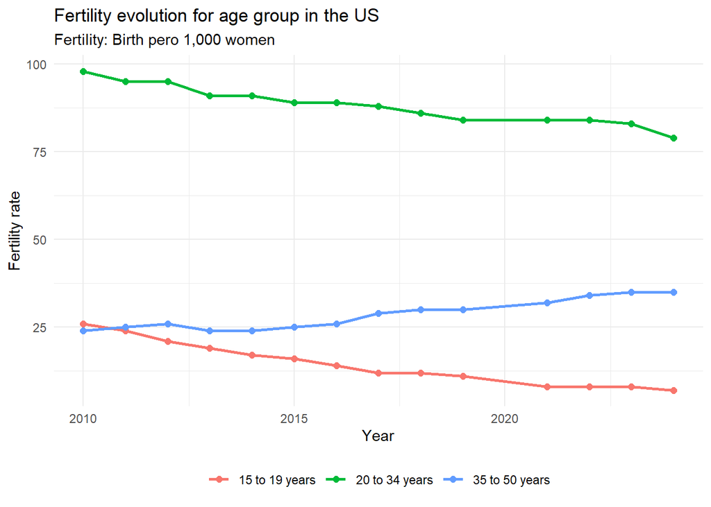

```r
# Plotting
plot_demographic_group(fertility_clean, labels_age, "Fertility evolution for age group in the US")
```

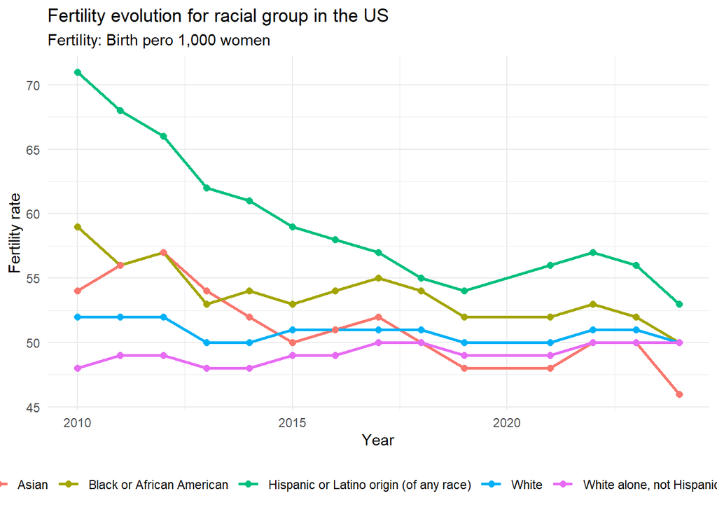

```r
plot_demographic_group(fertility_clean, labels_race, "Fertility evolution for racial group in the US")
```

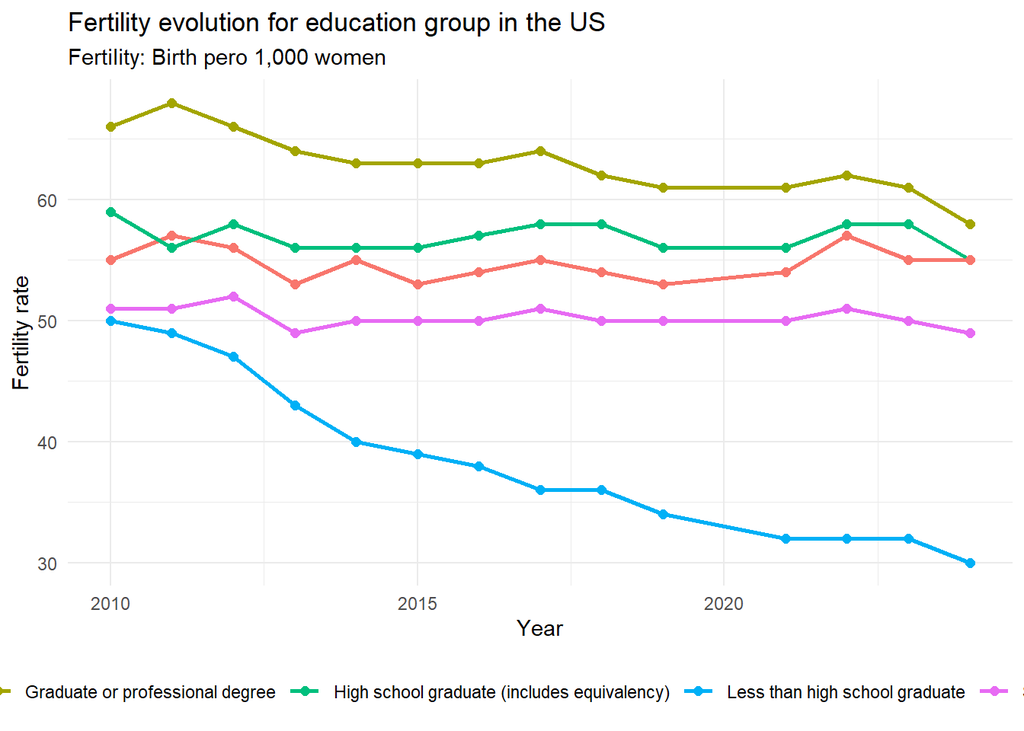

```r
plot_demographic_group(fertility_clean, labels_education, "Fertility evolution for education group in the US")
```

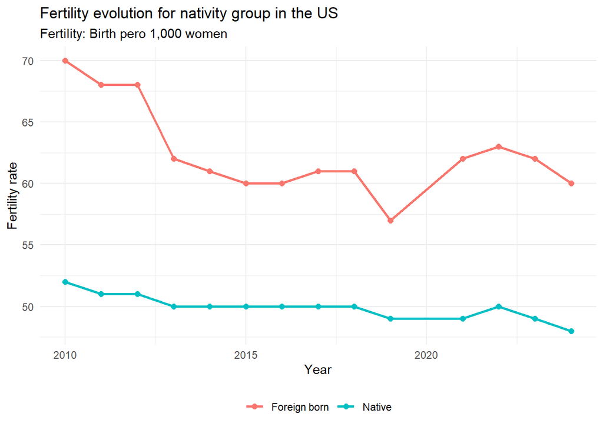

```r
plot_demographic_group(fertility_clean, labels_nativity, "Fertility evolution for nativity group in the US")
```

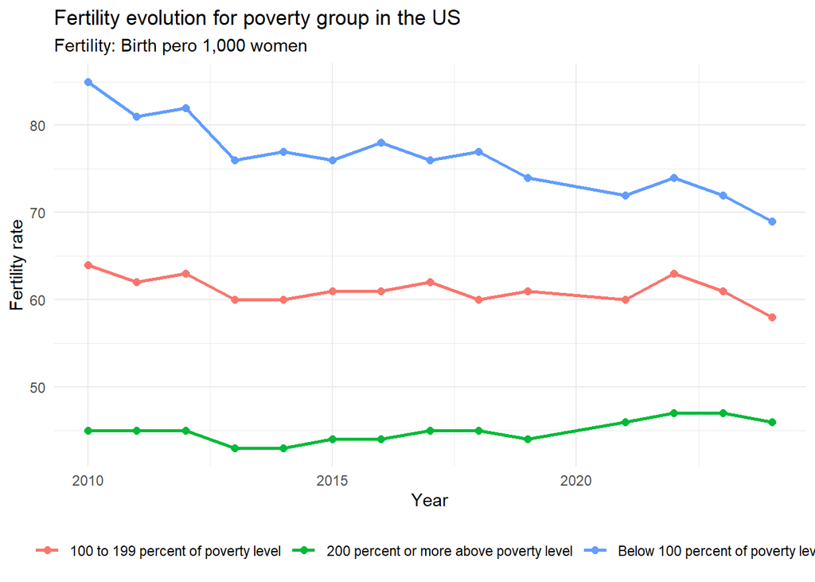

```r
plot_demographic_group(fertility_clean, labels_poverty, "Fertility evolution for poverty group in the US")
```

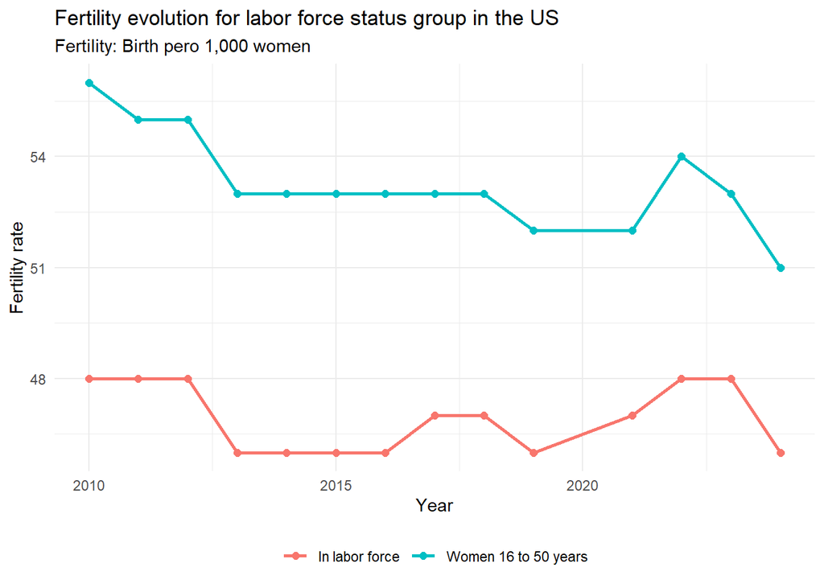

```r
plot_demographic_group(fertility_clean, labels_labor_force, "Fertility evolution for labor force status group in the US")
```

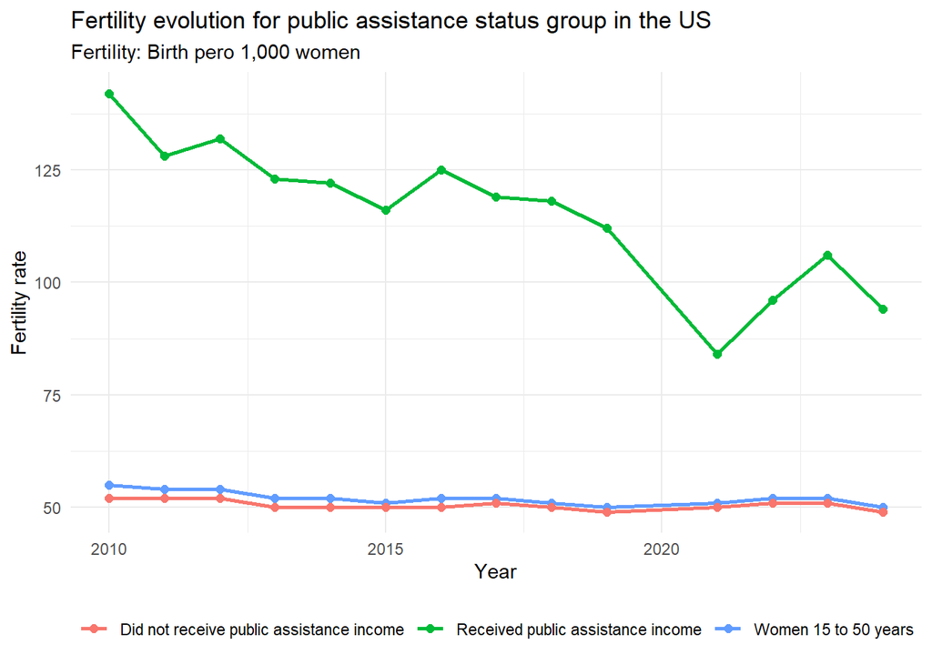

```r
plot_demographic_group(fertility_clean, labels_public_ass, "Fertility evolution for public assistance status group in the US")
```